# index

Max

2024-04-30

# Introduction

## Background

*Edmans et. al., 2007* performed an analysis on the influence of international sporting results on countries’ stock returns, finding that **national team losses predicted lower stock returns**. The researchers hypothesized that this effect was due to decreased investor mood.

Here’s a link to their study if you’re interested…

https://onlinelibrary.wiley.com/doi/epdf/10.1111/j.1540-6261.2007.01262.x?saml_referrer

I would like to perform a similar analysis of each UK country’s national football (soccer) results and the returns of FTSE 100 stocks, beginning in 2002 after the start of the Japan World Cup.

## Requirements

The code used loads of functions, and therefore required many libraries!

These included: library(tidyverse), library(here), library(tidyr), library(ggplot2), library(dplyr), library(plotly), library(gganimate), library(gifski), library(forcats), library(ggtext), library(scales), library(prismatic),

## Importing the Data

I used the here function to import the data, allowing this code to run on any computer which had downloaded the “psy6422_proj” folder

```r
#Import Datasets
ftse100pathway <- here("psy6422_proj", "data", "FTSE100_Data_2002_2024.csv")
ftse100 <- read.csv(ftse100pathway)

resultspathway <- here("psy6422_proj", "data", "results.csv")
results <- read.csv(resultspathway)

shootoutspathway <-
  here("psy6422_proj", "data", "shootouts.csv")
shootouts <- read.csv(shootoutspathway)
```

# Data Origins

### We first needed a record of UK stock data…

The Financial Times Stock Exchange 100 Index (ftse100) is a stock market formed from a collective of 100 of the UK’s most valuable companies. It is renowned as a solid reflection of UK stocks and UK investor behaviours in general.

The ftse100 dataset contains a huge collection of daily stock returns, showing the date of data collection (*Date*) as well as the highest (*High*), lowest (*Low*), and average (*Price*) stock values of that day. The dataset also presents the percentage at which stocks changed from the day before (*Change..*).

This data was sourced from: https://uk.investing.com/indices/uk-100-historical-data Investing.com is a financial website which provides free real-time stock data across 250 exchanges worldwide. They employ over 250 people to publish trustworthy data each day. https://uk.investing.com/about-us/

```r
head(ftse100)
```

```
##         Date    Price     Open     High      Low    Vol. Change..
## 1 21/02/2024 7,662.51 7,719.21 7,719.21 7,642.75   1.19B   -0.73%
## 2 20/02/2024 7,719.21 7,728.50 7,748.73 7,705.98 819.03M   -0.12%
## 3 19/02/2024 7,728.50 7,711.71 7,733.54 7,692.48 575.04M    0.22%
## 4 16/02/2024 7,711.71 7,597.53 7,720.72 7,597.53 996.23M    1.50%
## 5 15/02/2024 7,597.53 7,568.40 7,612.34 7,562.10 651.78M    0.38%
## 6 14/02/2024 7,568.40 7,512.28 7,590.13 7,512.28   1.14B    0.75%
```

### Next, we needed a record of international football matches since 2002…

The results dataset contains all international football results since 1872, detailing the date of each match (*date*), the current names of countries that played (*home_team* and *away_team*), the number of goals scored by each team (*home_score* and *away_score*), and the competition that each game was played in (*tournament*). Information was also provided regarding where the match was played and whether this was a neutral location or not (*neutral*).

This data was sourced from: https://www.kaggle.com/datasets/martj42/international-football-results-from-1872-to-2017

Unlike what the link itself suggests, this kaggle user collected data from international football matches starting from the very first official match in 1872 up to 2024. The dataset contains only men’s first team matches, and does not include matches from the Olympic Games. In the words of the user: “The data is gathered from several sources including but not limited to Wikipedia, rsssf.com, and individual football associations’ websites.”

```r
head(results)
```

```
##         date home_team away_team home_score away_score tournament    city
## 1 1872-11-30  Scotland   England          0          0   Friendly Glasgow
## 2 1873-03-08   England  Scotland          4          2   Friendly  London
## 3 1874-03-07  Scotland   England          2          1   Friendly Glasgow
## 4 1875-03-06   England  Scotland          2          2   Friendly  London
## 5 1876-03-04  Scotland   England          3          0   Friendly Glasgow
## 6 1876-03-25  Scotland     Wales          4          0   Friendly Glasgow
##    country neutral
## 1 Scotland   FALSE
## 2  England   FALSE
## 3 Scotland   FALSE
## 4  England   FALSE
## 5 Scotland   FALSE
## 6 Scotland   FALSE
```

### Finally, we needed data for any football matches that went to penalty shootouts…

```r
head(shootouts)
```

```
##         date   home_team        away_team      winner first_shooter
## 1 22/08/1967       India           Taiwan      Taiwan
## 2 14/11/1971 South Korea Vietnam Republic South Korea
## 3 07/05/1972 South Korea             Iraq        Iraq
## 4 17/05/1972    Thailand      South Korea South Korea
## 5 19/05/1972    Thailand         Cambodia    Thailand
## 6 21/04/1973     Senegal            Ghana       Ghana
```

The shootouts dataset contains data for every international penalty shootout since 1967. Once again, there is information showing the two teams that played (*home_team* and *away_team*) and the date of each shootout (*date*). Each row contains the winner of the shootout (*winner*), and some rows even show which team took the first penalty in the shootout (*first_shooter*).

This data was also sourced from: https://www.kaggle.com/datasets/martj42/international-football-results-from-1872-to-2017

## Research Questions

**Three research questions were created in this research project.**

*1. How have UK stock values changed over time?*

*2. How do the four UK national football teams differ?*

*3. Can national football results really have an impact on UK stock market values?*

Three visualisations were created in attempt to answer these questions.

# Plot One: How have UK stock values changed over time?

I wanted to create a line graph showing how daily ftse100 stock values have increased/decreased since January 2002. I then planned to animate the graph to better visualise how the line moves through time.

This Plot only required data from the ftse100 dataset

## Data Preperation

Before creating the plot, I needed to ensure that my variables of interest were in the correct format.

```r
#Convert date values to a date variable on R
ftse100$Date <- as.Date(ftse100$Date, format = "%d/%m/%Y")

#Convert Price to a numerical variable
ftse100$Price <- as.numeric(gsub(",", "", ftse100$Price)) #Remove confusing commas
ftse100$Price <- as.numeric(ftse100$Price)
```

## Creation

Before creating an animated plot, I needed to create one which wasn’t animated

```r
#Create the initial (not animated) plot
#Line graph
stockplot <- ggplot(ftse100,
            aes(x = Date, y = Price, color = Price)) +
  geom_line() +

  #Add heading and axis titles
  labs(title = "UK Stocks Since 2002",
       subtitle = paste("Change in FTSE100 Daily Stock Values from",
                        format(min(ftse100$Date), "%B %Y"),
                        "to",
                        format(max(ftse100$Date), "%B %Y")),
       x = "Year", y = "UK Stock Price (£)") +

  #Choose Theme
  theme_classic() +

  #Add Colour Scale
  colour_scale +

  #Determine X axis Labels every 2 years
  scale_x_date(date_breaks = "2 years", date_labels = "%Y") +

  #Add vertical dashed lines coming from the X axis labels
  geom_vline(xintercept = as.numeric(seq(min(ftse100$Date), max(ftse100$Date), by = "2 years")),
             color = "gray", linetype = "dashed", alpha = 0.5) +

  #Add data source below plot
  annotate("text", x = as.Date("2014-01-01"), y = min(ftse100$Price),
           label = "Data Source: https://uk.investing.com", hjust = 0, vjust = -1,
           color = "darkgray", size = 3) +

  #Colour code, add fonts, determine size of writing
  theme(
    panel.background = element_rect(fill = "#fbf9f4", color = "#fbf9f4"),
    plot.background = element_rect(fill = "#fbf9f4", color = "#fbf9f4"),
    panel.border = element_blank(),
    panel.grid.major.x = element_blank(),
    axis.title.x = element_text(color = "#1b2860"),
    axis.title.y = element_text(color = "#1b2860"),
    plot.title = element_text(
      family = "sans",
      size = 20,
      face = "bold",
      color = "#1b2860"),
    plot.title.position = "plot", # slightly different from default
    axis.text = element_text(
      family = "sans",
      size = 10,
      color = "#1b2860"),
    axis.title = element_text(
      family = "sans",
      size = 12))
```

Only then could I animate the line using the transition_reveal function

```r
stocks_animated <- stockplot + transition_reveal(Date) +
  enter_fade() +
  exit_fade()
```

## The Visualisation

Animated gifs are unfortunately not supported by all PDF outputs. Here is a visualisation of the linegraph before animation.

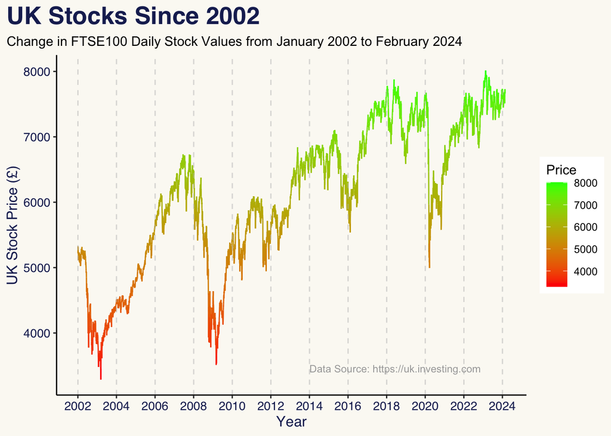

```r
print(stockplot)
```

## Discussion

This is a line graph showing the ups and downs of ftse100 stock prices since the 1st of January, 2002. Higher stock values are coloured in a positive green, whilst drops in values are coloured in a negative red. Dashed vertical lines also give reference for the 2-year breaks labelled on the x axis.

There is a general increase in stock values, but this has been paired with some harsh dips. One dip that is interesting to note occurs just after the start of the year 2020. The COVID pandemic really affected investor behaviour!

# Plot Two: How do the four UK national football teams differ?

For my next plot, I wanted to create a dumbbell chart showing how each UK nation’s football team differ in their individual results.

## Data Preperation

Before beginning the second (and third!) analyses, I needed to merge the stocks, results, and shootouts datasets. Merging the results and shootouts datasets was necessary for the second plot as i wanted to present a statistical visualisation of how each UK nation has performed in all of their football matches.

I first ensured that the values from all date variables were characterised as dates, and merged the datasets using the dates as well as the teams which played for the results and shootouts datasets.

```r
#Convert all date values to a date variable on R
ftse100$Date <-
  as.Date(ftse100$Date, format = "%d/%m/%Y")

results$date <-
  as.Date(results$date, format = "%Y-%m-%d")

shootouts$date <-
  as.Date(shootouts$date, format = "%d/%m/%Y")


#Merge Datasets using this Date variable
data <-
  merge(ftse100, results,
        by.x = "Date",
        by.y = "date",
        all = TRUE)
data <-
  merge(data, shootouts,
        by.x = c("Date", "home_team", "away_team"),
        by.y = c("date", "home_team", "away_team"),
        all.x = TRUE)
```

```r
#Fill in missing Stock data
#Some days do not have stock data
#This code adds to missing info using the next known stock values

data <- data[order(data$Date), ]
data <- data %>%
  fill(Price, Open, High, Low, Vol., Change.., .direction = "down")
```

We then needed to create a new variable showing who won football matches. So far we only had the winners of games that went to penalties. We needed to add to the already created winner variable without changing its present values

```r
#Determine which rows need filling in the winner variable
newwinners <- is.na(data$winner)


#If home_score > away_score, put the home team in winner variable
#If away_score > home_score, put the away team in winner variable
#If else (scores are even), put "draw"
data$winner[newwinners] <-

  ifelse(data$home_score[newwinners] > data$away_score[newwinners],
         data$home_team[newwinners],

         ifelse(data$home_score[newwinners] < data$away_score[newwinners],
                data$away_team[newwinners],

                "draw"))
```

Rows without any football matches allocated to them were then removed, and a sanity check was performed to see if this all went through ok.

```r
#Remove Rows with no Football Match
data <- data[complete.cases(data$home_team), ]

#Sanity check
head(data)
```

```
##         Date home_team away_team Price Open High  Low Vol. Change.. home_score
## 1 1872-11-30  Scotland   England    NA <NA> <NA> <NA> <NA>     <NA>          0
## 2 1873-03-08   England  Scotland    NA <NA> <NA> <NA> <NA>     <NA>          4
## 3 1874-03-07  Scotland   England    NA <NA> <NA> <NA> <NA>     <NA>          2
## 4 1875-03-06   England  Scotland    NA <NA> <NA> <NA> <NA>     <NA>          2
## 5 1876-03-04  Scotland   England    NA <NA> <NA> <NA> <NA>     <NA>          3
## 6 1876-03-25  Scotland     Wales    NA <NA> <NA> <NA> <NA>     <NA>          4
##   away_score tournament    city  country neutral   winner first_shooter
## 1          0   Friendly Glasgow Scotland   FALSE     draw          <NA>
## 2          2   Friendly  London  England   FALSE  England          <NA>
## 3          1   Friendly Glasgow Scotland   FALSE Scotland          <NA>
## 4          2   Friendly  London  England   FALSE     draw          <NA>
## 5          0   Friendly Glasgow Scotland   FALSE Scotland          <NA>
## 6          0   Friendly Glasgow Scotland   FALSE Scotland          <NA>
```

A new dataset specific for the creation of plot 2 was made, and all unneeded colums were removed.

```r
#Create new dataset for plot 2
df_footy <- data

#Remove Unneeded Columns
df_footy <-
  subset(df_footy, select = -c(Price, Open, High, Low, Vol., Change.., city, country, first_shooter))
```

I wanted to see how nations had differed in their wins, losses, draws. I therefore created a new dataset showing these variables, called nationstats.

We first needed the stats of when each team was the home team, and then performed the same methods on when each team was the away team

```r
nationstats <- df_footy %>%
  group_by(team = home_team) %>%   #Create variable named "team" for each national football team
  summarise(
    games_played = n(),   #Total games played by how many times they are in home_team
    games_won = sum(winner == home_team),   #If team is in winner, they won the game
    games_lost = sum(winner != home_team & winner != "draw")   #If team is not winner and the game was not a draw, put down as a loss
  ) %>%
  ungroup() %>%  # Remove grouping
  bind_rows(  #Bind rows to this dataset using the same process for away teams
    df_footy %>%
      group_by(team = away_team) %>%
      summarise(
        games_played = n(),
        games_won = sum(winner == away_team),
        games_lost = sum(winner != away_team & winner != "draw")
      )) %>%
  arrange(desc(games_played))  # Arrange by total games played, descending
```

Two rows for each team were created by this code. One showed the statistics for when a team was the home team, and the other showed statistics for when the team was the away team. The next job was to bind these rows together to show total matches/wins/losses

```r
nationstats <- nationstats %>%
  group_by(team) %>%
  summarise(
    games_played_total = sum(games_played),
    games_won_total = sum(games_won),
    games_lost_total = sum(games_lost),
    .groups = "drop"  # Ensure that grouped data is returned as a flat data frame
  )

#Check the new dataset looks ok
head(nationstats)
```

```
## # A tibble: 6 × 4
##   team           games_played_total games_won_total games_lost_total
##   <chr>                       <int>           <int>            <int>
## 1 Abkhazia                       28              14                8
## 2 Afghanistan                   129              34               65
## 3 Albania                       371             100              191
## 4 Alderney                       19               3               16
## 5 Algeria                       569             263              165
## 6 American Samoa                 48               4               42
```

I was only interested in data from the four UK countries. These are: England, Scotland, Wales, and Northern Ireland. I therefore filtered the dataset to only show the values of these teams.

```r
#Determine which nations i want to keep
countries_to_keep <-
  c("England", "Scotland", "Wales", "Northern Ireland")

#Create new dataset with only values of those teams
UKfooty <- nationstats %>%
  filter(team %in% countries_to_keep)

#View new dataset
head(UKfooty)
```

```
## # A tibble: 4 × 4
##   team             games_played_total games_won_total games_lost_total
##   <chr>                         <int>           <int>            <int>
## 1 England                        1059             608              209
## 2 Northern Ireland                683             176              353
## 3 Scotland                        824             393              255
## 4 Wales                           702             225              321
```

## Creation

I also set the themes for the visualisation in advance, alongside the title and subtitles that I wished to show.

```r
#Create Plot
UKFootballPlot = ggplot(UKfooty, aes(x = share, y = team)) +

  #dumbbell segments
  stat_summary(
    geom = "linerange", fun.min = "min", fun.max = "max",
    linewidth = c(rep(.8, n), 1.2), color = c(rep(blue_base, n), blue_dark)
  ) +

  #dumbbell points
  #white point to go over line endings
  geom_point(
    aes(x = share), size = 6, shape = 21, stroke = 1, color = "white", fill = "white"
  ) +
  #semi-transparent point fill
  geom_point(
    aes(x = share, fill = type), size = 6, shape = 21, stroke = 1, color = "white", alpha = .7
  ) +
  #point outline
  geom_point(
    aes(x = share), size = 6, shape = 21, stroke = 1, color = "white", fill = NA
  ) +

  #result labels
  geom_text(
    aes(label = percent(share, accuracy = 1, prefix = "    ", suffix = "%    "),
        x = share -0.02, hjust = is_smaller-0.32, color = type),
    fontface = c(rep("plain", n*2), rep("bold", 2)),
    family = "sans", size = 4.2
  ) +

  #legend labels
  annotate(
    geom = "text", x = c(.18, .60), y = n + 1.8,
    label = c("matches lost", "matches won"), family = "sans",
    fontface = "bold", color = pal_base, size = 5, hjust = .5
  ) +

  coord_cartesian(clip = "off") +   #Prevent clipping of points
  scale_x_continuous(expand = expansion(add = c(.035, .05)), guide = "none") +   #Expand x-axis and remove x-axis guide
  scale_y_discrete(expand = expansion(add = c(.35, 1))) +   #Expand y axis
  scale_color_manual(values = pal_dark) +   #Set colour scale for lines
  scale_fill_manual(values = pal_base) +   #Set fill scale for points
  labs(title = title, caption = caption) +   #Set plot title and caption
  theme(axis.text.y = element_text(face = "bold", size=14))   #Set y axis text to bold and adjust size
```

The plot was then saved as a png file in the correct dimensions so all information could be shown.

## The Visualisation

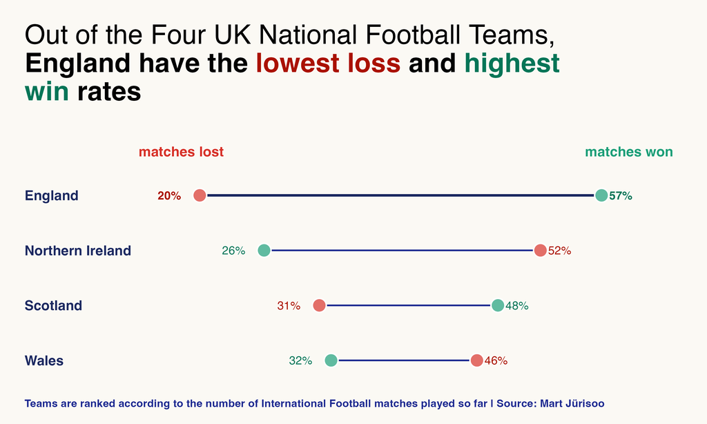

```r
knitr::include_graphics("psy6422_proj/figs/ukfootballplot.png")
```

## Discussion

# Plot 3: Can national football results really have an impact on UK stock market values?

The final analysis was the one I was most looking forward to! Will positive or negative football results influence the UK’s most reliable stock market in the ftse100?

## Data Preperation

To start, I once again had to determine my countries of interest and filter out any matches not containing UK countries. I then removed any rows that contained values occurring before the first of January, 2002. The dataset was then cleaned of any unneeded variables.

```r
#Set countries of interest
countries_to_keep <-
  c("England", "Scotland", "Wales", "Northern Ireland")

#Keep rows if UK country is a home or away team
data <-
  data[data$home_team %in% countries_to_keep |
         data$away_team %in% countries_to_keep, ]


#Remove data before 2002
remove_date <- as.Date("2002-01-01")
data <- data[data$Date >= remove_date, ]


#Remove Unneeded Columns
data <-
  subset(data, select = -c(Open, High, Low, Vol., city, country, first_shooter))


#Check data looks ok
head(data)
```

```
##             Date        home_team        away_team  Price Change.. home_score
## 25043 2002-02-13      Netherlands          England 5153.9    0.35%          1
## 25044 2002-02-13 Northern Ireland           Poland 5153.9    0.35%          1
## 25051 2002-02-13            Wales        Argentina 5153.9    0.35%          1
## 25111 2002-03-27          England            Italy 5214.7    0.37%          1
## 25113 2002-03-27           France         Scotland 5214.7    0.37%          5
## 25116 2002-03-27    Liechtenstein Northern Ireland 5214.7    0.37%          0
##       away_score tournament neutral winner
## 25043          1   Friendly   FALSE   draw
## 25044          4   Friendly    TRUE Poland
## 25051          1   Friendly   FALSE   draw
## 25111          2   Friendly   FALSE  Italy
## 25113          0   Friendly   FALSE France
## 25116          0   Friendly   FALSE   draw
```

Using the same process as before, match winners were added to the “winner” variable without overriding any values there already from penalty shootouts.

I then needed to create a variable to show how each UK team had faired in their match. In an ideal world this would be easy, as i could just see if a UK team was playing and check if they are in the winner variable. However, UK teams often play against each other, so this process would allocate every one of these games as a UK win (unless it was a draw of course).

I therefore decided to prioritise the result of a country with highest population. Using this logic, if winner of a match was England, the result would show win. If the winner was Scotland, show win if England didn’t play. If winner is Wales, show win if England or Scotland didn’t play. If winner is Northern Ireland, only show win if England, Scotland, or Wales didn’t play. If the winner variable showed draw, obviously I would want the result variable to say draw. Finally, if anything else was the case (the winner was not a UK country or draw), the result variabe would show loss.

Here’s the function I created to do this:

```r
get_result <- function(winner, home_team, away_team) {
  if (winner == "draw") {
    return("draw")
  } else if (winner == "England") {
    return("win")
  } else if (winner == "Scotland") {
    if ("England" %in% c(home_team, away_team)) {
      return("loss")
    } else {
      return("win")
    }
  } else if (winner == "Wales") {
    if ("England" %in% c(home_team, away_team) || "Scotland" %in% c(home_team, away_team)) {
      return("loss")
    } else {
      return("win")
    }
  } else if (winner == "Northern Ireland") {
    if ("England" %in% c(home_team, away_team) || "Scotland" %in% c(home_team, away_team) || "Wales" %in% c(home_team, away_team)) {
      return("loss")
    } else {
      return("win")
    }
  } else {
    return("loss")
  }
}

# Apply the function to dataset
data$result <- mapply(get_result, data$winner, data$home_team, data$away_team)
```

I then ensured that my variable showing percentage changes in stock prices was a numerical variable, before ordering my results columns in the order: win, draw, loss so that it looks good on the plot.

Using the same techniques as before, I filtered out games from any competitions that were not international tournaments. Friendly games, qualifiers, and the recently created “nations league” very rarely generate as much attention as the much larger World Cup or EUROs tournament games, and so I decided to focus on the impact of these games on the stock market.

Finally, I calculated the total number of matches that fitted into the win, draw, and loss conditions. The aim was to add this information to the plot using the ggplotly function.

```r
#Calculate number of each condition
result_n <- tournament_data %>%
  group_by(result) %>%
  summarize(count = n())
```

## Creation

Here is the code I used to create the template for the third visualisation.

```r
#Create Plot 3

tournaments_plot <- ggplot(tournament_data %>%  # Start with tournament data
                             group_by(result) %>%  # Group by tournament result
                             summarize(Mean_Change = mean(Change..)),  # Summarize mean change for each result
                           aes(x = result, y = Mean_Change, fill = result,  # Define aesthetics
                               text = paste("Result:", result,  # Tooltip text
                                            "<br>Mean UK Stock Change (%):", round(Mean_Change, 3),
                                            "<br>Number of Values:", result_n$count[result]))) +  # Include count of values

  geom_bar(  # Add bar plot
    stat = "identity",  # Use identity statistics
    position = "identity",  # Use identity position
    width = 0.8,  # Set bar width
    colour = "#1b2860",  # Set border color
    size = 0.3) +  # Set border size

  # Set plot labels
  labs(title = "Football and The Stock Market",
       x = "UK International Football Result (WC and EUROs only)",
       y = "Mean Stock Value Change (%)",
       subtitle = "Can UK National Teams' Football Results Influence Daily FTSE100 Stock Prices?") +

  # Set fill colors manually
  scale_fill_manual(values = c("win" = "#1b9e77", "draw" = "#fdae61", "loss" = "#d73027"),
                    name = NULL) +

  # Set plot theme
  theme_light() +  # Set light theme
  theme(
    panel.background = element_rect(fill = "#fbf9f4", color = "#fbf9f4"),  # Set panel background
    plot.background = element_rect(fill = "#fbf9f4", color = "#fbf9f4"),  # Set plot background
    panel.border = element_blank(),  # Remove panel border
    panel.grid.major.x = element_blank(),  # Remove major gridlines on x-axis
    axis.title.x = element_text(color = "#1b2860"),  # Set x-axis title color
    axis.title.y = element_text(color = "#1b2860"),  # Set y-axis title color
    plot.title = element_text(  # Set plot title text properties
      family = "sans",  # Set font family
      size = 20,  # Set font size
      face = "bold",  # Set font face
      color = "#1b2860"),  # Set font color
    axis.text = element_text(  # Set axis text properties
      family = "sans",  # Set font family
      size = 10,  # Set font size
      color = "#1b2860"),  # Set font color
    axis.title = element_text(  # Set axis title properties
      family = "sans",  # Set font family
      size = 12)) +  # Set font size

  geom_hline(yintercept = 0, linetype = "solid", color = "#1b2860") +  # Add horizontal line at y = 0 for reference
  guides(fill = "none")  # Remove fill legend
```

I then converted this plot into an interactive plot using ggplotly. One thing I had to note was that the code to make subtitles needed to be specifically tailored to the ggplotly function, meaning that these had to be written in after I had made the plot interactive.

```r
#Make the plot interactive
tournaments_animated <- ggplotly(tournaments_plot, tooltip = "text")

#A seperate process was needed to include a subtitle to the interactive plot
tournaments_animated <- tournaments_animated %>%
  layout(
    annotations = list(
      text = "Can UK National Teams' Football Results Influence Daily FTSE100 Stock Prices?",
      x = 0, y = 1.04,
      font = list(size = 14, color = "black", family = "sans"),
      xref = "paper", yref = "paper",
      showarrow = FALSE
    )
  )



#Add Data Sources
#Add a text annotation for the stock data source
tournaments_animated <- tournaments_animated %>%
  layout(
    annotations = list(
      text = "Stock Data Source: https://uk.investing.com",
      x = 1,
      y = 0.85,  # Adjust the y-coordinate to position the text at the bottom
      xref = "paper",
      yref = "paper",
      showarrow = FALSE,
      font = list(
        family = "sans",
        size = 10,  # Adjust the font size as needed
        color = "darkgrey"
      )
    )
  )


# Add a text annotation for the football data source
tournaments_animated <- tournaments_animated %>%
  layout(
    annotations = list(
      text = "Football Data Source: Mart Jürisoo",
      x = 1,
      y = 0.9,  # Adjust the y-coordinate to position the text at the bottom
      xref = "paper",
      yref = "paper",
      showarrow = FALSE,
      font = list(
        family = "sans",
        size = 10,  # Adjust the font size as needed
        color = "darkgrey"
      )
    )
  )
```

## The Visualisation

Unfortunately the ggplotly version of this plot did not seem to work on a PDF. Here is the non-interactive version.

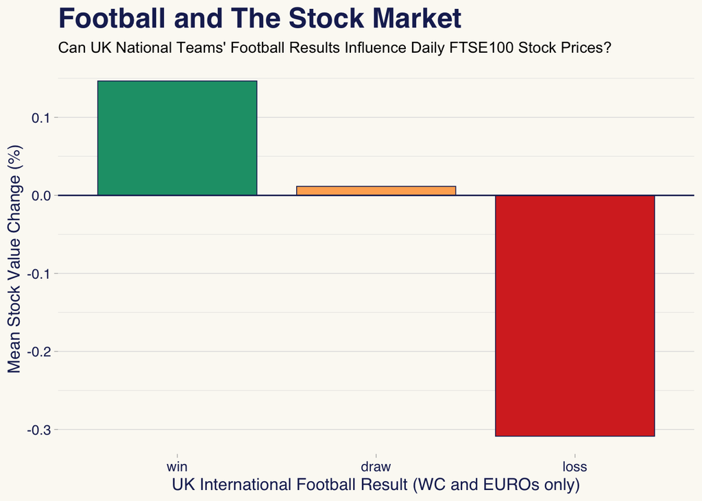

```r
print(tournaments_plot)
```

## Discussion

Perhaps a larger analysis (such as Edmans’ study) would find greater significance in the small differences between the win/loss conditions, due to the greater sample of football matches to go through. Only analysing the data of four football teams from a relatively short time frame would not have allowed me to determine whether these small football-related stock value changes were truly meaningful.

## Summary

Throughout this module I have had the opportunity to really develop my understanding of data science as a whole. I feel much more confident handling and analysing large datasets, and I believe I have really improved upon my ability to create attractive but also informative visualisations.

This module has set me up with skills that I am sure could take me down a number of career pathways. Thank you to Tom and Hazel for teaching and supporting this module in an encouraging and enthusiastic manner. It really was a pleasure to take part in the lab classes each week.